# Strava Fitness Analysis

Author

Shelby Cyr, Daniel Rabi, and Ali Sachwani

Published

March 7, 2026

# The Task

1. Explain how you define fitness.
2. Tell me about which individual is fitter?
3. Tell me about which individual has improved more in fitness?
4. Make a clear and concise recommendation on which individual you would want to coach. There is no `it depends here`, you have to make a decision.

Write a bullet point summary on your findings at the beginning of the document.

You must use a quarto document (.qmd) and render it into `html`.

# Bullet Point Summary:

- The definition we have used for fitness is: “The condition of being physically strong and healthy”
- Collie is more Fit.
- Collie has improved more in fitness.
- Our choice on who we want to coach is Collie.

# What is Fitness?

According to @Cambridge_nd, the definition of fitness is “the condition of being physically strong and healthy,” and @Healthlinkbc_2022 expands on that definition by adding the ability to perform physical activity. Therefore, to understand what makes an individual fit, we need to understand what enables an individual to perform physical activity and which metrics we can use to track performance. Since our analysis will focus on fitness in running, we will running specific metrics.

## Relevant Metrics:

- Stride Length:

  “The distance you cover with each step of your run” [@Leicht_2023]. Additionally, @Vasudevan_2025 suggests that knowing a person’s stride length can help detect a tendency to overstride, which can help prevent injuries, such as knee injuries.
- Cadence:

  “The number of steps you take in one minute” [@Leicht_2023]. Furthermore, @Nike_2026 explains that cadence is important because it can be used to optimize an athlete’s ground contact time, explain abnormal stride length, and running inefficiency. For instance, a lower cadence often means longer contact time with the ground, which in turn means a longer stride length. A longer stride length could mean pushing the foot too far ahead of the athlete’s body, which can cause knee injuries and result in wasted energy and loss of performance [@Nike_2026].

## Performance measures:

- Training Effect:

  According to @Zhao_2019, Training Effect measures how each training session affects VO2 Max (Maximum Volume of Oxygen) improvement. Furthermore, @Harvard_2024 suggests that VO2 Max can indicate an individual’s fitness because a high VO2 Max correlates with better physical fitness and is also associated with “a lower risk for cardiovascular disease and increased longevity.” The reason VO2 Max correlates with better physical fitness and health is that it measures the amount of oxygen an athlete consumes during exercise [@Harvard_2024]. Oxygen consumption matters, for muscles to generate energy as ATP, the more oxygen the athlete can breathe in, the more energy the muscle can produce to perform the exercise [@Harvard_2024].

  @Zhao_2019 suggests the following description for the Training Effect ranges:
  - 0.0 - 0.9: No aerobic effect
  - 1.0 - 1.9: Minor aerobic effect
  - 2.0 - 2.9: Maintaining aerobic effect
  - 3.0 - 3.9: Improving aerobic effect
  - 4.0 - 4.9: Highly improving aerobic effect
  - 5.0: Overreaching aerobic effect

  Aerobic Training Effect will be a more important measurement in our analysis of the rate of improvement.
- Efficiency Factor:

  According to @nxtrun_2025, the efficiency factor (EF) is a performance measure that quantifies the speed an individual achieves per heartbeat. EF matters because an efficient individual uses less oxygen, therefore, they need less energy from the heart to pump oxygen to the muscles to maintain a given speed.

  @nxtrun_2025 and @Friel suggest that the efficiency factor calculation is the following:

  $$EF = \frac{\text{Speed}}{\text{Heart Rate}}$$

  Since we have an average pace, we can use it to find the average speed, because pace and speed are inverses. This means that:

  $$\text{Speed} = \frac{1}{\text{Pace}}$$

It is important to note that Training Effect is a short-term performance measure which only tracks the Max VO2 improvement from a single workout. In contrast, the Efficiency Factor is useful for long-term performance tracking because it relates speed to heart rate. This allows us to observe improvements in running efficiency over time. Therefore, to determine who is more fit, we will primarily use the Efficiency Factor.

- SAD:

Given the importance of both the Efficiency Factor (EF) and the Training Effect (TE), we decided to create our own metric. The Shelby Ali Daniel (SAD) metric aims to combine the strengths of both measures by assigning 80% to EF and 20% to TE to make a definitive decision on which runner to train. This metric will be explored in more detail later in the report.

To better understand how different running metrics affect performance, we computed correlation matrices for each runner.

# Correlation Analysis

**Hound’s Correlation Matrix:**

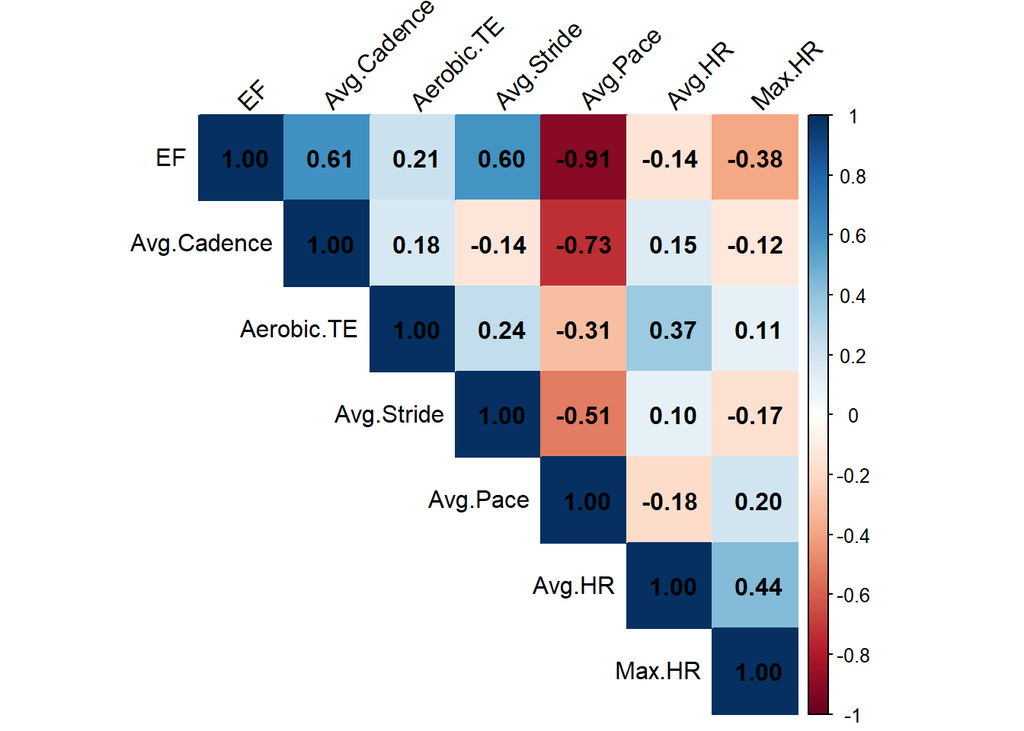

**Collie’s Correlation Matrix:**

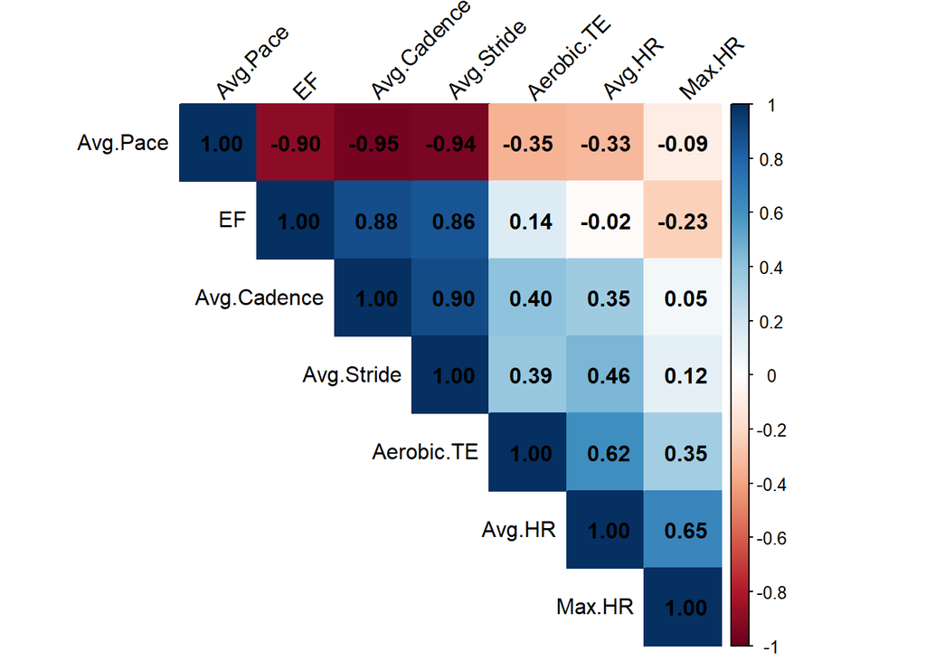

Looking at the matrices, we can see that both Hound and Collie exhibit strong negative correlations with the average pace of -0.91 and -0.90, respectively. The negative correlation between Efficiency Factor and Average Pace indicates that the faster the individual runs, the more efficient they become. Hound shows a strong positive correlation between Efficiency Factor and both Cadence and Stride, with coefficients of 0.61 and 0.60, respectively. On the other hand, Collies show an even stronger positive correlation between Efficiency Factor and both Cadence and Stride, with coefficients of 0.88 and 0.86, respectively. The correlation strength suggests that Collie’s efficiency is more strongly associated with consistent running basics, the Cadence and Stride, which may help later explain why Collie’s overall Efficiency Factor is higher. In contrast, as expected, the Training Effect showed relatively weak correlations with most of the dataset, since it is a short-term measure.

Overall, the correlation analysis suggests that the Efficiency Factor is closely related to running speed and running basics, particularly pace, cadence, and stride length. While both runners exhibit these relationships, Collie shows stronger correlations between efficiency and running basics, indicating a more consistent link between technique and performance. These patterns help explain why Collie tends to achieve higher overall efficiency compared with Hound.

# Training Effect (TE) Analysis

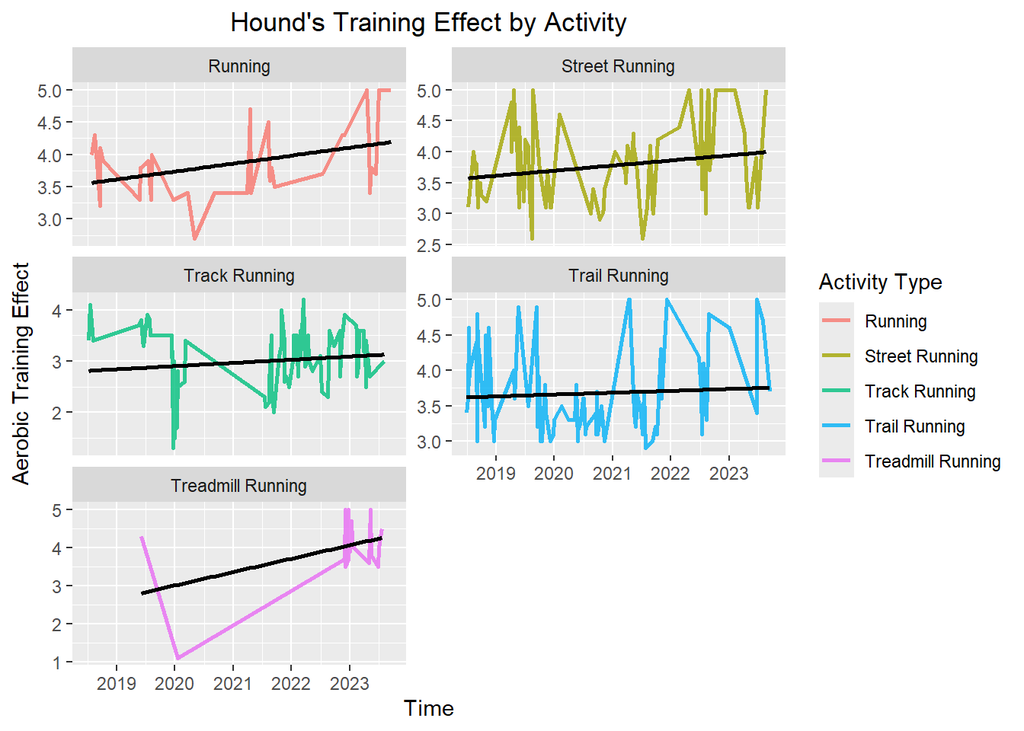

The Training Effect charts show that Hound’s aerobic improvement varies substantially across activity types and over time. Most observations fall within the moderate to high Training Effect range of approximately 3.0 to 5.0, suggesting that many sessions produce meaningful aerobic improvement. Running and Street Running frequently reach the upper portion of this range and display a slight upward trend over time. In contrast, Track Running tends to remain lower and more uneven, often fluctuating around moderate values. Trail Running exhibits the largest variability, with Training Effect values alternating between moderate and very high levels across sessions. While most activities show slight positive trends, the changes are relatively modest, indicating that Hound’s aerobic improvement remains broadly stable over time. Overall, the results suggest that Hound’s training improvement is distributed across multiple activity types and is somewhat dependent on the type of workout performed.

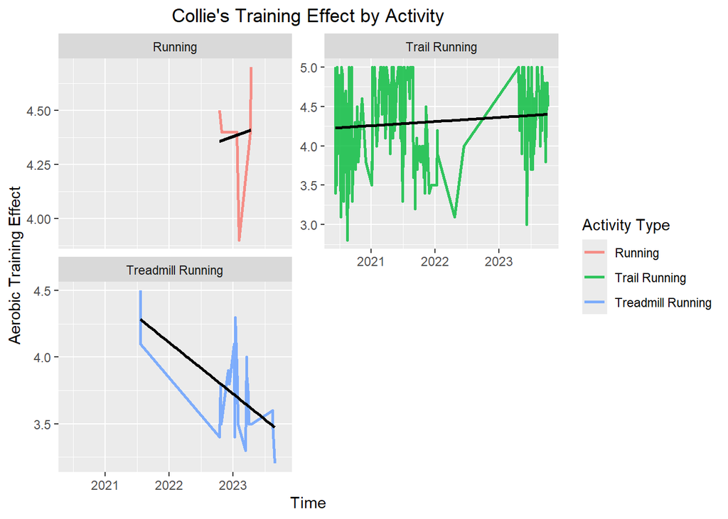

First, it is important to note that Collie does not have observations for Street Running or Track Running, suggesting these activities were either not performed or not recorded in the dataset. Most of Collie’s runs occur in Trail Running, which also corresponds to the highest and most consistent Training Effect values. Trail sessions are frequently clustered between 4.0 and 5.0, indicating consistently strong aerobic stimulus. Additionally, the trend line for the Trail Running activity also shows a slight upward movement over time, suggesting gradual improvement or sustained high training intensity. Running appears less frequently in the dataset but also remains within the upper range of the Training Effect scale. Treadmill Running exhibits somewhat lower values and a downward trend, although the number of observations is limited. Overall, Collie’s training pattern appears more focused on a single activity type and consistently delivers a high aerobic stimulus.

Ultimately, compared to Hound, Collie’s Training Effect appears less dispersed across the observed activities and more consistently positioned near the upper end of the scale. Overall, the comparison suggests that Collie produces a stronger aerobic training stimulus more regularly. In contrast, Hound shows a broader range of moderate and high training effects across activity types and periods.

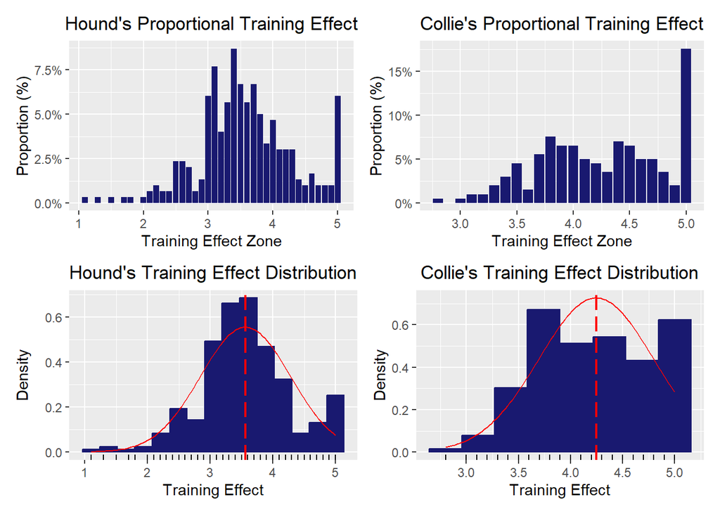

These proportional Training Effect charts reinforce the idea that Collie’s aerobic stimulus is concentrated at a higher level than Hound’s. Hound’s distribution is centered more heavily in the middle of the Training Effect scale, with the greatest mass appearing around roughly 3.0 to 4.0. Hound’s Training Effect mean suggests that many of Hound’s sessions produce moderate to substantial improvements in aerobic fitness. However, Hound’s distribution is more spread out, including some lower values and a smaller share of very high-end observations. In other words, Hound’s training effect profile appears broader and more mixed, with sessions ranging from relatively weak to strong aerobic stimulus, but with most observations clustered in the middle range rather than at the very top.

In contrast, Collie’s proportional distribution is shifted more toward the upper end of the scale. A substantial share of Collie’s observations falls between about 4.0 and 5.0, and there is a particularly noticeable concentration at 5.0. Collie’s higher Training Effect mean indicates that Collie frequently records high improving or overreaching aerobic effects compared with Hound. Relative to Hound, Collie has fewer observations in the lower and middle parts of the Training Effect range and a larger proportion in the highest zones. In aggregate, these charts suggest that Collie’s runs more consistently generate stronger aerobic training stimulus, whereas Hound’s runs are distributed more evenly across moderate and high Training Effect levels.

Overall, both runners regularly achieve moderate to high Aerobic Training Effect values, indicating that their sessions frequently produce meaningful aerobic stimulus. However, the patterns differ in consistency and intensity. Hound’s Training Effect is more widely distributed across the scale, with many observations in the moderate-to-high range and greater variation across sessions and activity types. On the other hand, Collie’s Training Effect is more concentrated near the upper end of the scale, with a large share of sessions falling between roughly 4.0 and 5.0. Collie’s higher mean value suggests that Collie’s runs are more consistently strong, whereas Hound’s training reflects a broader mix of moderate and high-intensity efforts.

# Efficiency Factor (EF) Analysis

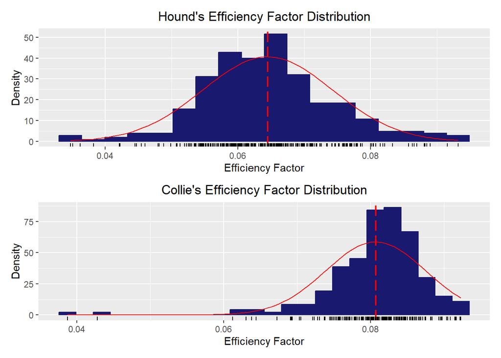

The Efficiency Factor charts indicate that Collie demonstrates a stronger overall running efficiency than Hound. Since the Efficiency Factor measures the speed produced per heartbeat, a higher value suggests that a runner can generate greater running output for a given cardiovascular effort. Hound’s distribution appears centred at a lower level, around 0.064, and is more widely spread across the sample, suggesting both lower average efficiency and greater variation from run to run. The wider spread implies that Hound’s performance is less stable, with sessions ranging from relatively efficient to noticeably less efficient outcomes. By contrast, Collie’s distribution is skewed to the left, with most observations concentrated near 0.081. The higher Efficiency Factor mean for Collie indicates that he generally maintains a higher speed relative to heart rate across runs, consistent with better running efficiency.

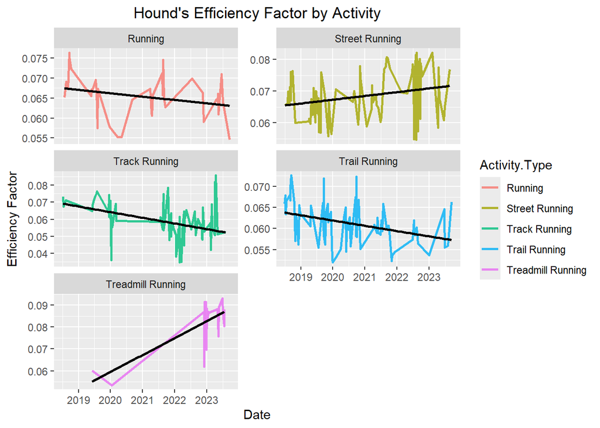

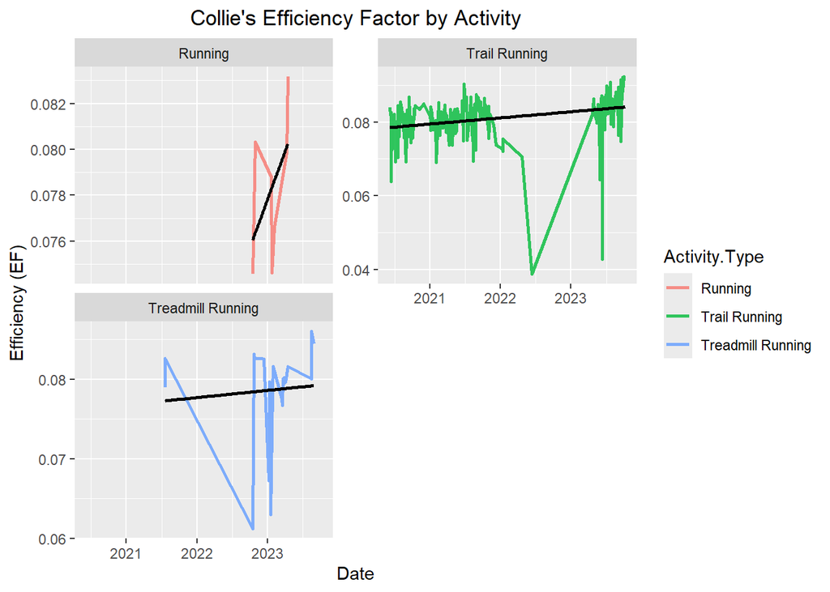

The Efficiency Factor for the activity-specific plots reinforce the earlier interpretation that Collie generally demonstrates higher running efficiency than Hound. Hound’s Efficiency Factor varies noticeably across activity types, with several visible downward trends over time. Although Hound occasionally records higher efficiency values, these are interspersed with lower observations. This results in greater variability across sessions and running environments. In contrast, Collie’s Efficiency Factor values are not only higher overall but also more concentrated within a narrower range, particularly in running and trail running. The regression lines for Collie also suggest slightly improving or stable efficiency over time in most activities. Even when temporary declines appear, Collie’s efficiency levels generally remain above Hound’s typical values. Overall, the activity-specific patterns indicate that Collie maintains more consistent and higher efficiency across sessions, whereas Hound exhibits greater variability and somewhat lower average efficiency.

# Fitness Analysis

## Current Fitness Level

To assess the current fitness level of the two runners, Hound and Collie, we will primarily use the Efficiency Factor. Therefore, based on our analysis of the Efficiency Factor, we found that Hound’s EF is normally distributed around an average of 0.064. In contrast, Collie’s EF is left-skewed around an average of 0.081. The findings from the EF distributions suggest that **Collie is clearly more fit** than Hound, as his distribution is highly consistent around a higher average Efficiency Factor.

## Most Improved In Fitness

To determine who improved the most, we initially looked at the Efficiency Factor over time. Based on this, we found that Hound was inconsistent in his improvement, showing improvement in some activity types and a decline in others. Collie consistently showed improvement across all activity types. However, the difference in overall Efficiency Factor improvement was not large enough for us to make a conclusive decision based solely on the efficiency factor. For this reason, we also decided to look at both of their Training Effects. Our analysis of Aerobic Training Effects shows that Hound consistently maintains a TE in the 3-4 zone with his average being 3.56. While this does indicate that according to Aerobic TE scores he will be consistently improving it will be at a smaller magnitude when compared to someone who’s Aerobic TE scores are higher. Looking at Collie’s Aerobic TE scores we can see that he consistently has scores in the 3.5-5 range with an average of 4.25. This indicates that according to Aerobic TE his improvement after each workout will be greater. Based on these factors **Collie has improved more in fitness.**

## Coaching Decision

For assessing improvement, trend-based measures are more useful than single-run values. Raw EF and TE from a single session may be influenced by daily factors such as fatigue, route, weather, or workout intensity, so they are limited as direct measures of improvement on their own. Our custom combined metric is helpful here because it summarizes both efficiency and training quality in one score.

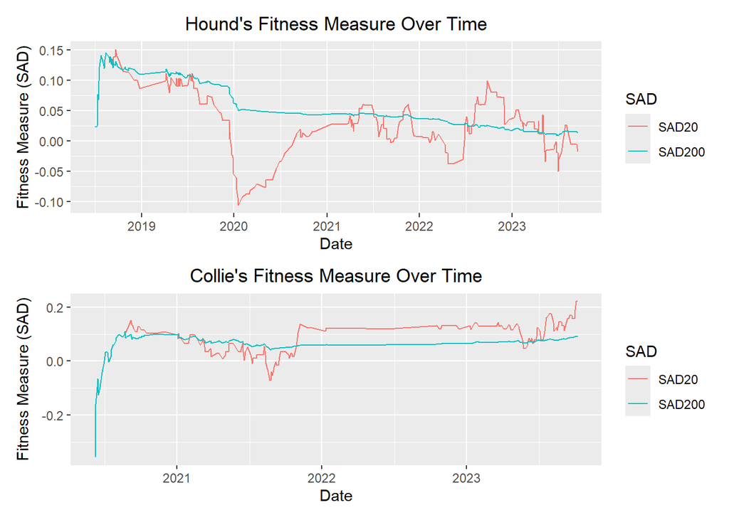

The fitness metric we developed is a custom performance measure designed to combine efficiency and aerobic training effect into a single score. It is made up of the following components:

The first component is Efficiency Factor (EF), which captures how much speed is being produced relative to heart rate. In this case, pace is converted into speed, and EF is calculated as speed divided by average heart rate. A higher EF suggests that the runner is moving faster for a given cardiovascular effort, which can be interpreted as better efficiency.

The second component is Aerobic Training Effect (TE), which reflects the physiological impact of the run. Based on the TE interpretation ranges already provided in the document, TE is converted into a custom score that increases as the aerobic effect becomes more meaningful, with the highest reward assigned to strongly improving aerobic effect levels. In our metric, a TE of 5 is assigned a score of 0, since it represents an overreaching effect and is treated in this metric as excessively fatiguing rather than ideal for regular training. This scoring structure is intended to reward productive aerobic stimulus without automatically rewarding maximal effort. Since EF and the TE score are measured on different scales, they are first scaled before being combined.

The final metric is intended to summarize both how efficiently the run was performed and how productive the training stimulus was. It is weighted using an 80/20 ratio, with 80% assigned to EF and 20% assigned to the TE score. The goal of this metric is not to create a perfect universal measure of performance, but rather to build a practical session-quality indicator that can be tracked over time to identify whether recent running performance and training quality are improving, declining, or remaining stable.

We used moving averages to smooth out short-term fluctuations in the custom performance metric and make the underlying trend easier to see. Because individual run scores can vary from session to session due to factors such as fatigue, conditions, or workout type, the raw series can be noisy and hard to interpret. The shorter moving average captures more recent changes, while the longer moving average provides a broader view of the overall pattern over time. Together, they make it easier to evaluate how the metric is changing across runs rather than focusing too heavily on isolated observations.

To examine the custom metric over time, moving averages based on 20 and 200 observations were computed. The 20-observation moving average provides a short-run view of the metric and responds more quickly to recent fluctuations, whereas the 200-observation moving average provides a smoother long-run representation of the series. Plotting both moving averages helps reduce short-term noise and makes the time-series behavior of the metric easier to visualize.

Our recommendation is to coach **“Collie”**. Based on the use of this custom metric and the moving-average graphs, Collie shows the stronger upward pattern in the custom metric over time, especially in the longer-run 200-observation average, which gradually rises across the sample. The shorter-run 20-observation average also spends much of the later period above the longer-run average, indicating stronger recent performance relative to Collie’s own longer-term trend. In contrast, Hound’s 200-observation average trends downward over time, and the 20-observation average is more volatile, with larger swings above and below the longer-run line. Taken together, the graphs suggest that Collie provides the clearer case for coaching support because the recent trajectory of the metric is more favorable and shows stronger momentum in the underlying performance trend.

## **References**

Cambridge University Press. (n.d.). *Fitness*. Cambridge Dictionary. Retrieved https://dictionary.cambridge.org/dictionary/english/fitness

Friel, J. (n.d.). *What is running efficiency and how is it measured?* Training Peak. Retrieved https://www.trainingpeaks.com/blog/the-efficiency-factor-in-running/

Healthwise Staff. (2022, October 10). *Fitness: Getting and staying active*. Health Link BC. https://www.healthlinkbc.ca/healthwise/fitness-getting-and-staying-active

Leicht, L. (2023, May 4). *8 running metrics to help you track your fitness*. Runners World. https://www.runnersworld.com/training/a43793832/running-metrics-guide/

Nike. (2026, January 9). *What is cadence running? How to find your optimal step rate and improve performance*. https://www.nike.com/ca/a/what-is-cadence-running

Nxt Run. (2025, August 6). *What the f is ’EF’ and how can it be used in my training*. https://www.nxtrun.ai/post/what-is-ef

Vasudevan, J. (2025, February 25). *Everything you need to know about stride length*. Runners World. https://www.runnersworld.com/uk/training/beginners/a46820832/stride-length/

Warner, L. (2024, July 8). *VO2 max: What is it and how can you improve it?* Harvard Health Publishing. https://www.health.harvard.edu/staying-healthy/vo2-max-what-is-it-and-how-can-you-improve-it

Zhao, X. (2019, September 8). *How should i improve my aerobic fitness?* Medium. https://medium.com/@xinzhao13/understanding-how-my-wearables-understands-my-workout-285699b9deda